# Western horse mackerel adults parameters for DEPM

mkorta modified from DEPM_mackerel_script of PSanpedro

4/7/2023

*Maria Korta, Paula Álvarez and Cindy Van Damme. Presentation WGMEGS meeting,April 17-21 Madrid.*

# 1 Raw Data Summary

## 1.1 Tables

**By period**

```
## # A tibble: 1 x 2
##   Period nMatFem_C
##   <fct>      <int>
## 1 7            191
```

```
## # A tibble: 1 x 2
##   Period nMatFem_H
##   <fct>      <int>
## 1 7             48
```

Sampled by period.

| Period | nHaul | nFish | R_nFish | D_nFish | nMatFem | nSpawFem | nMatFem_C | nMatFem_H | nPOFAge | nNcent |
| --- | --- | --- | --- | --- | --- | --- | --- | --- | --- | --- |
| 6 | 15 | 800 | 792 | 8 | 382 | 38 | 276 | 265 | 167 | 39 |
| 7 | 20 | 858 | 828 | 30 | 401 | 79 | 311 | 168 | 104 | 32 |
| Total | 35 | 1658 | 1620 | 38 | 783 | 117 | 587 | 433 | 271 | 71 |

```r
# ---- Legend ------ #

# nHaul:     No. of hauls.
# nFish:     No. of individual fish measured.
# R_nFish:   No. of individual fish randomly sampled and measured.
# D_nFish:   No. of individual fish sampled by direct sampling and measured.
# nMatFem:   No. of mature females.
# nSpawFem:  No. of mature females in maturity stage 4 (Hydrated).
# nMatFem_C: No. of ovaries from mature females that were collected.
# nMatFem_H: No. of ovaries from collected mature females that were histologically screened.
# nPOFAge:   No. of ovaries assigned as "with presence of POF" in histological screening.
# nNcent:    No. of ovaries analysed for batch fecundity.

# ------------------ #
```

- Ideally 1840 ovaries were planned to collect and finally 587 ovaries were retained (32%).

**By haul**

Samples by Haul.

Period

Haul

Long

Lat

country

nFish

nFemales

nMatFem

nSpawFem

nMatFem_C

nMatFem_H

nPOFAge

nNcent

6

2022NL5400606

-11.9000

52.7300

WMR

1

1

1

0

1

1

0

0

6

2022NL5400607

-11.2500

51.8000

WMR

12

7

7

1

7

5

2

0

6

2022NL5400608

-8.6800

50.7300

WMR

36

19

19

0

19

13

4

1

6

2022NL5400609

-10.7300

50.6700

WMR

100

72

72

2

30

28

16

6

6

2022NL5400610

-10.8200

49.2300

WMR

107

34

34

14

34

34

26

7

6

2022NL5400611

-8.6500

48.2300

WMR

100

53

53

5

32

32

21

7

6

2022NL5400613

-5.3000

47.2000

WMR

101

38

38

11

33

33

28

9

6

2022NL5400614

-7.3200

47.7500

WMR

100

31

31

2

31

31

22

3

6

2022NL5400615

-9.8000

48.8700

WMR

100

55

55

1

30

30

16

0

6

1

-6.4800

47.5700

WESPAS

40

25

25

1

20

20

10

2

6

2

-7.0700

47.5900

WESPAS

5

2

2

0

1

1

0

0

6

3

-6.1600

48.0800

WESPAS

2

0

0

0

0

0

0

0

6

9

-9.3100

49.5900

WESPAS

50

26

26

1

26

26

18

3

6

10

-9.7600

50.3300

WESPAS

23

12

12

0

8

7

2

1

6

13

-10.1900

51.0800

WESPAS

23

7

7

0

4

4

2

0

7

2022NL5000740

-10.4200

51.2700

WMR_PFA

50

19

19

6

16

16

10

6

7

2022NL5000741

-10.8800

51.5800

WMR_PFA

50

25

21

2

13

13

9

2

7

2022NL5000742

-11.7300

52.5800

WMR_PFA

50

31

31

6

18

18

11

5

7

2022NL5000743

-11.4500

52.1500

WMR_PFA

50

27

27

2

12

12

8

3

7

2022NL5000744

-10.9000

51.4800

WMR_PFA

50

17

17

3

9

9

5

0

7

AE22010

-13.3480

53.4928

MSS

1

1

1

1

1

0

0

0

7

AE22011

-10.9650

51.7100

MSS

57

27

24

15

24

6

3

0

7

AE22012

-11.0500

49.3250

MSS

100

44

42

18

40

10

4

2

7

AE22013

-5.8440

47.2645

MSS

53

21

21

3

21

6

1

1

7

AE22014

-6.5537

47.4980

MSS

6

5

5

1

5

1

1

0

7

AE22015

-10.7680

50.0160

MSS

100

41

41

3

40

10

4

0

7

AE22016

-10.9900

51.4300

MSS

100

57

53

9

30

7

4

0

7

AE22017

-9.9210

54.8830

MSS

100

45

45

7

30

8

2

1

7

14

-10.6100

51.3300

WESPAS

16

4

4

0

4

4

3

2

7

15

-11.0000

51.3300

WESPAS

2

0

0

0

0

0

0

0

7

16

-10.5700

51.6000

WESPAS

36

33

33

3

33

33

27

8

7

17

-10.8700

52.3400

WESPAS

1

0

0

0

0

0

0

0

7

20

-13.9000

53.3400

WESPAS

4

1

1

0

1

1

0

0

7

21

-11.5800

53.3500

WESPAS

28

15

15

0

13

13

11

2

7

40

-8.1900

55.9000

WESPAS

4

1

1

0

1

1

1

0

Total

-344.9597

1775.3193

1658

796

783

117

587

433

271

71

## 1.2 Plots

**Geographical distribution of nFish**

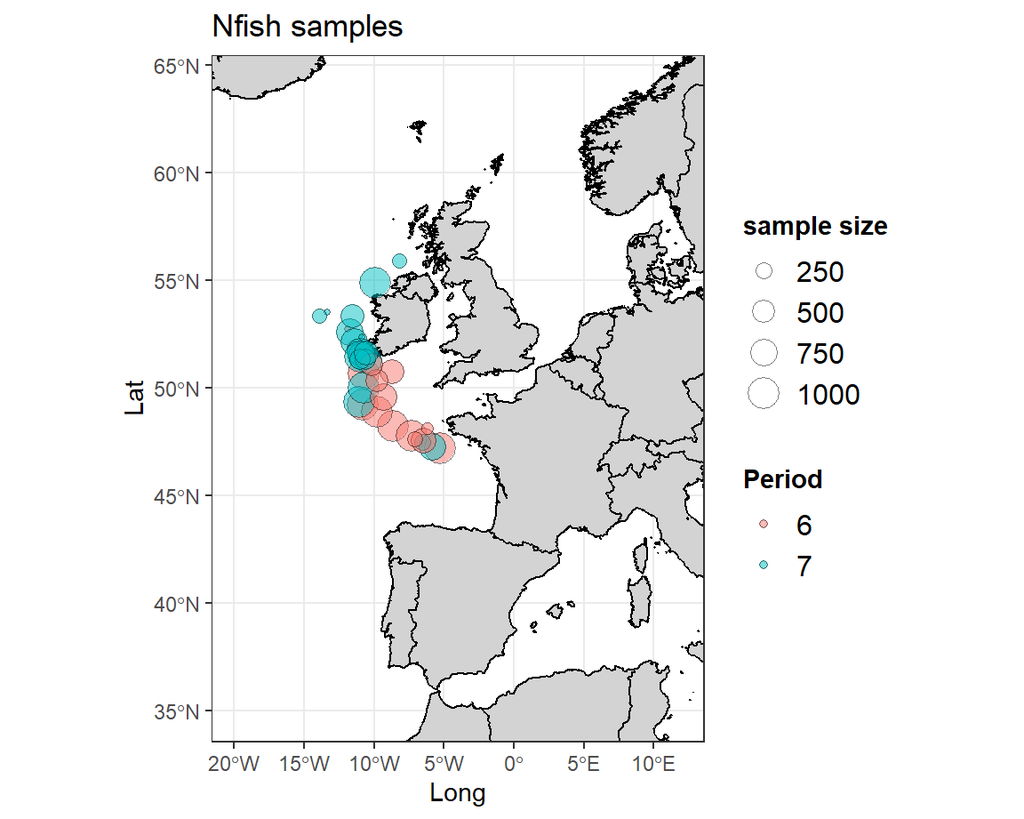

**Length and weight**

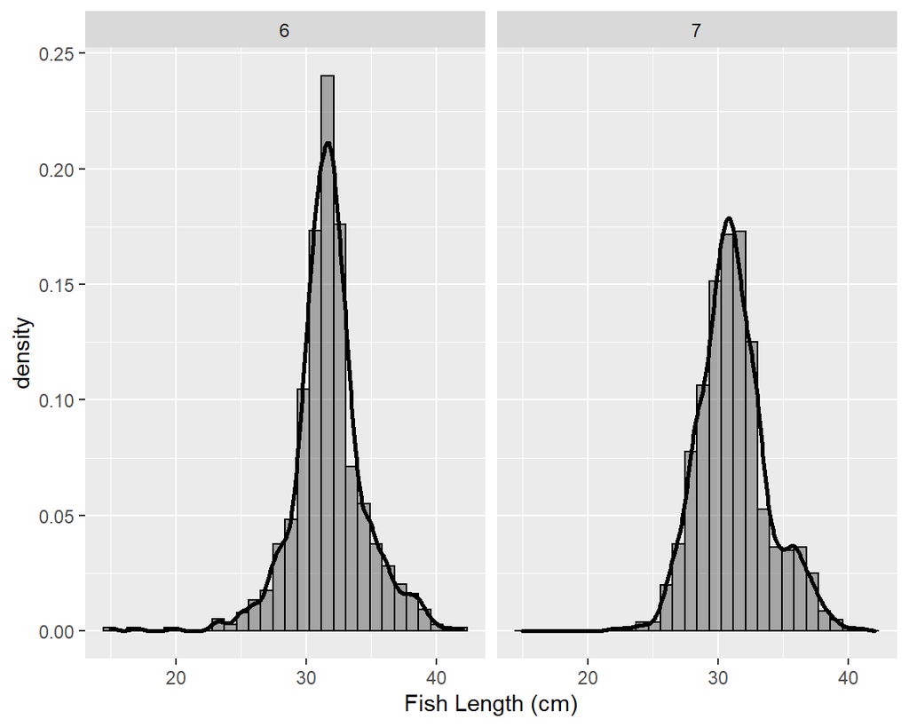

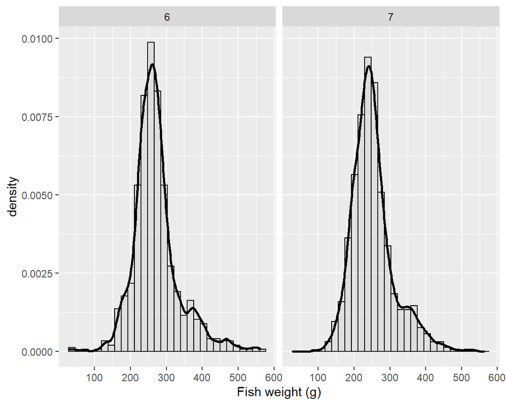

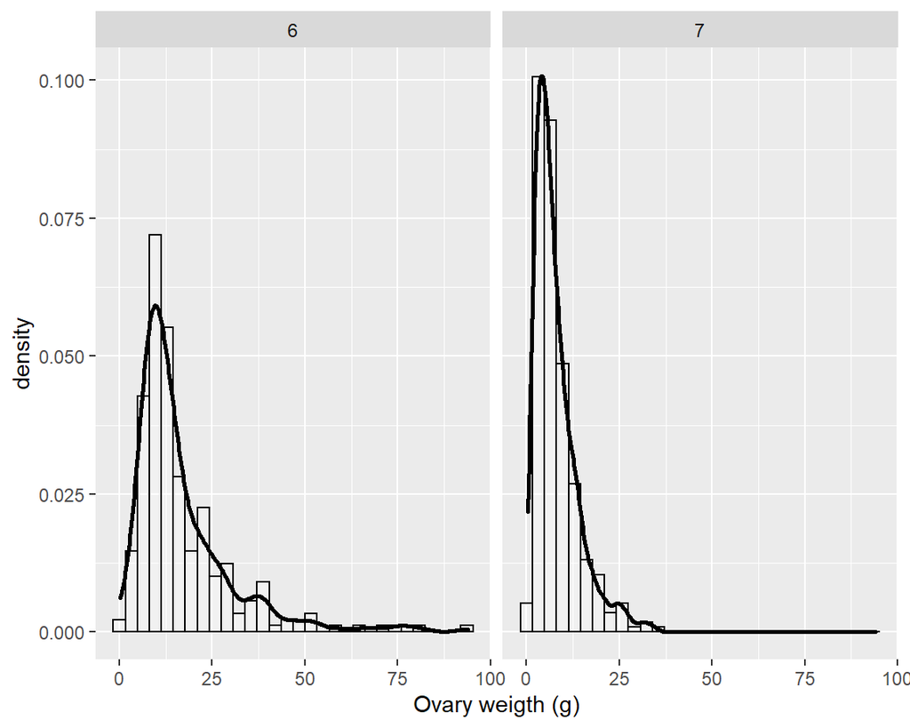

- The modal lenght in both periods is around 32 cm, less marked in period 7 with a second shallower moda.
- Fish weight distribution are quite similar.
- The ovaries weight distribution differes a little bit among periods; being more probable to observe heavier ovaries in period 6 than in period 7.
- Despite this, there are twice as many spawning females in period 7 than in period 6.

# 2 Paremeters by haul and Period

```r
# Wh:   Mean weight of mature females
# Rh:   Sex-ratio
# Fh:   Batch fecundity (the mean female expected batch fecundity)
# Sh:   Spawning fraction ratio
```

## 2.1 Total Weight correction

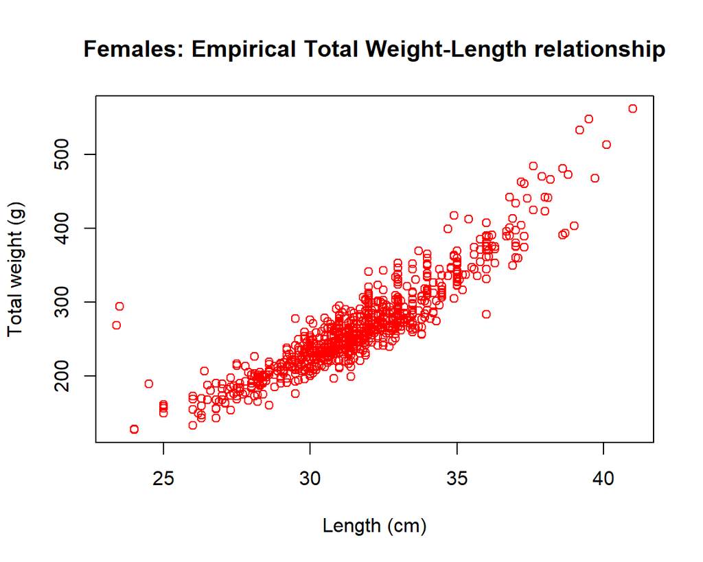

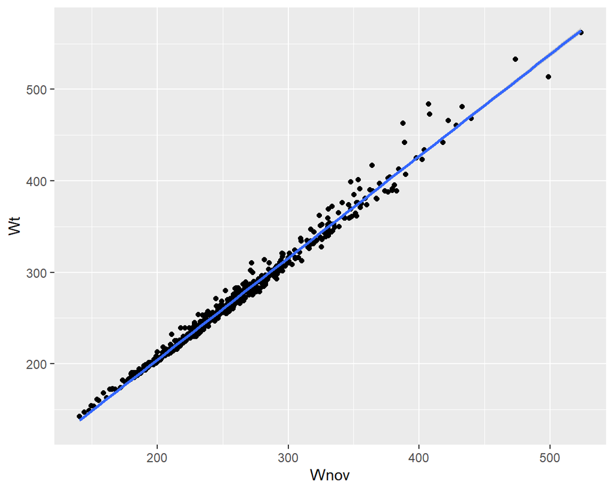

```r
# (Intercept)        Wnov
#  -17.859440     1.112043
#  Adjusted R-squared:  0.9864
```

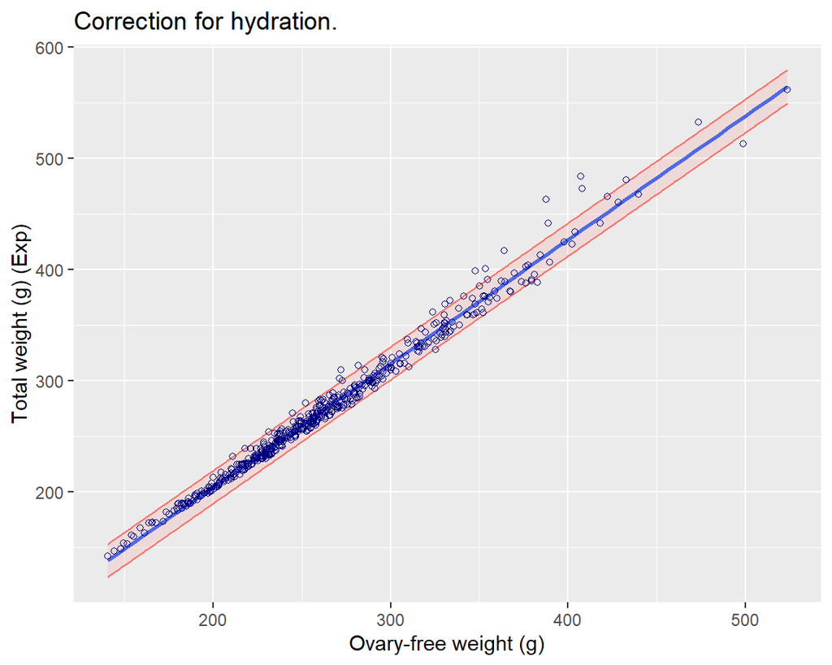

- The Length-Weight relationship was corrected from the bias due to hydration, and the expected Total weight was calculated for all females with the parameters obtained from the total weight-ovary free weight regression.
- The expected total weight was then used for adult parameters calculations.

## 2.2 Female mean weight (Wh)

Parameters: Wh by haul (auxiliar).

| Period | Haul | N | nMales | nFemales | n.Females.R | Wh |
| --- | --- | --- | --- | --- | --- | --- |
| 6 | 1 | 40 | 15 | 25 | 25 | 303.360 |
| 6 | 10 | 23 | 11 | 12 | 12 | NA |
| 6 | 13 | 23 | 16 | 7 | 7 | NA |
| 6 | 2 | 5 | 3 | 2 | 2 | NA |
| 6 | 2022NL5400606 | 1 | 0 | 1 | 1 | NA |
| 6 | 2022NL5400607 | 12 | 5 | 7 | 7 | NA |
| 6 | 2022NL5400608 | 36 | 17 | 19 | 19 | NA |
| 6 | 2022NL5400609 | 100 | 28 | 72 | 72 | 301.530 |
| 6 | 2022NL5400610 | 107 | 73 | 34 | 27 | 230.083 |
| 6 | 2022NL5400611 | 100 | 47 | 53 | 53 | 257.861 |
| 6 | 2022NL5400613 | 101 | 63 | 38 | 37 | 277.510 |
| 6 | 2022NL5400614 | 100 | 69 | 31 | 31 | 280.111 |
| 6 | 2022NL5400615 | 100 | 45 | 55 | 55 | 240.869 |
| 6 | 3 | 2 | 2 | 0 | 0 | NA |
| 6 | 9 | 50 | 24 | 26 | 26 | 323.948 |
| 7 | 14 | 16 | 12 | 4 | 4 | NA |
| 7 | 15 | 2 | 2 | 0 | 0 | NA |
| 7 | 16 | 36 | 3 | 33 | 3 | NA |
| 7 | 17 | 1 | 1 | 0 | 0 | NA |
| 7 | 20 | 4 | 3 | 1 | 1 | NA |
| 7 | 2022NL5000740 | 50 | 31 | 19 | 19 | NA |
| 7 | 2022NL5000741 | 50 | 25 | 21 | 21 | 220.056 |
| 7 | 2022NL5000742 | 50 | 19 | 31 | 31 | 257.604 |
| 7 | 2022NL5000743 | 50 | 23 | 27 | 27 | 228.520 |
| 7 | 2022NL5000744 | 50 | 33 | 17 | 17 | NA |
| 7 | 21 | 28 | 13 | 15 | 15 | NA |
| 7 | 40 | 4 | 3 | 1 | 1 | NA |
| 7 | AE22010 | 1 | 0 | 1 | 1 | NA |
| 7 | AE22011 | 57 | 27 | 24 | 24 | 237.619 |
| 7 | AE22012 | 100 | 55 | 42 | 42 | 222.976 |
| 7 | AE22013 | 53 | 32 | 21 | 21 | 361.755 |
| 7 | AE22014 | 6 | 1 | 5 | 5 | NA |
| 7 | AE22015 | 100 | 59 | 41 | 41 | 243.254 |
| 7 | AE22016 | 100 | 43 | 53 | 53 | 209.925 |
| 7 | AE22017 | 100 | 55 | 45 | 45 | 260.248 |

## 2.3 Sex ratio (Rh)

Parameters: Rh by haul (auxiliar).

| Period | Haul | N | nMales | nFemales | n.Females.R | Wh | TotNh | Rh |
| --- | --- | --- | --- | --- | --- | --- | --- | --- |
| 6 | 1 | 40 | 15 | 25 | 25 | 303.360 | 40 | 0.502 |
| 6 | 10 | 23 | 11 | 12 | 12 | NA | 23 | 0.487 |
| 6 | 13 | 23 | 16 | 7 | 7 | NA | 23 | 0.483 |
| 6 | 2 | 5 | 3 | 2 | 2 | NA | 5 | NA |
| 6 | 2022NL5400606 | 1 | 0 | 1 | 1 | NA | 1 | NA |
| 6 | 2022NL5400607 | 12 | 5 | 7 | 7 | NA | 12 | NA |
| 6 | 2022NL5400608 | 36 | 17 | 19 | 19 | NA | 36 | 0.491 |
| 6 | 2022NL5400609 | 100 | 28 | 72 | 72 | 301.530 | 100 | 0.523 |
| 6 | 2022NL5400610 | 107 | 73 | 34 | 27 | 230.083 | 100 | 0.490 |
| 6 | 2022NL5400611 | 100 | 47 | 53 | 53 | 257.861 | 100 | 0.507 |
| 6 | 2022NL5400613 | 101 | 63 | 38 | 37 | 277.510 | 100 | 0.513 |
| 6 | 2022NL5400614 | 100 | 69 | 31 | 31 | 280.111 | 100 | 0.502 |
| 6 | 2022NL5400615 | 100 | 45 | 55 | 55 | 240.869 | 100 | 0.523 |
| 6 | 3 | 2 | 2 | 0 | 0 | NA | 2 | NA |
| 6 | 9 | 50 | 24 | 26 | 26 | 323.948 | 50 | 0.525 |
| 7 | 14 | 16 | 12 | 4 | 4 | NA | 16 | NA |
| 7 | 15 | 2 | 2 | 0 | 0 | NA | 2 | NA |
| 7 | 16 | 36 | 3 | 33 | 3 | NA | 6 | NA |
| 7 | 17 | 1 | 1 | 0 | 0 | NA | 1 | NA |
| 7 | 20 | 4 | 3 | 1 | 1 | NA | 4 | NA |
| 7 | 2022NL5000740 | 50 | 31 | 19 | 19 | NA | 50 | 0.517 |
| 7 | 2022NL5000741 | 50 | 25 | 21 | 21 | 220.056 | 46 | 0.488 |
| 7 | 2022NL5000742 | 50 | 19 | 31 | 31 | 257.604 | 50 | 0.491 |
| 7 | 2022NL5000743 | 50 | 23 | 27 | 27 | 228.520 | 50 | 0.510 |
| 7 | 2022NL5000744 | 50 | 33 | 17 | 17 | NA | 50 | 0.518 |
| 7 | 21 | 28 | 13 | 15 | 15 | NA | 28 | 0.478 |
| 7 | 40 | 4 | 3 | 1 | 1 | NA | 4 | NA |
| 7 | AE22010 | 1 | 0 | 1 | 1 | NA | 1 | NA |
| 7 | AE22011 | 57 | 27 | 24 | 24 | 237.619 | 51 | 0.520 |
| 7 | AE22012 | 100 | 55 | 42 | 42 | 222.976 | 97 | 0.485 |
| 7 | AE22013 | 53 | 32 | 21 | 21 | 361.755 | 53 | 0.489 |
| 7 | AE22014 | 6 | 1 | 5 | 5 | NA | 6 | NA |
| 7 | AE22015 | 100 | 59 | 41 | 41 | 243.254 | 100 | 0.502 |
| 7 | AE22016 | 100 | 43 | 53 | 53 | 209.925 | 96 | 0.494 |
| 7 | AE22017 | 100 | 55 | 45 | 45 | 260.248 | 100 | 0.504 |

## 2.4 Batch fecundity (Fh)

**Geographical distribution_nCent**

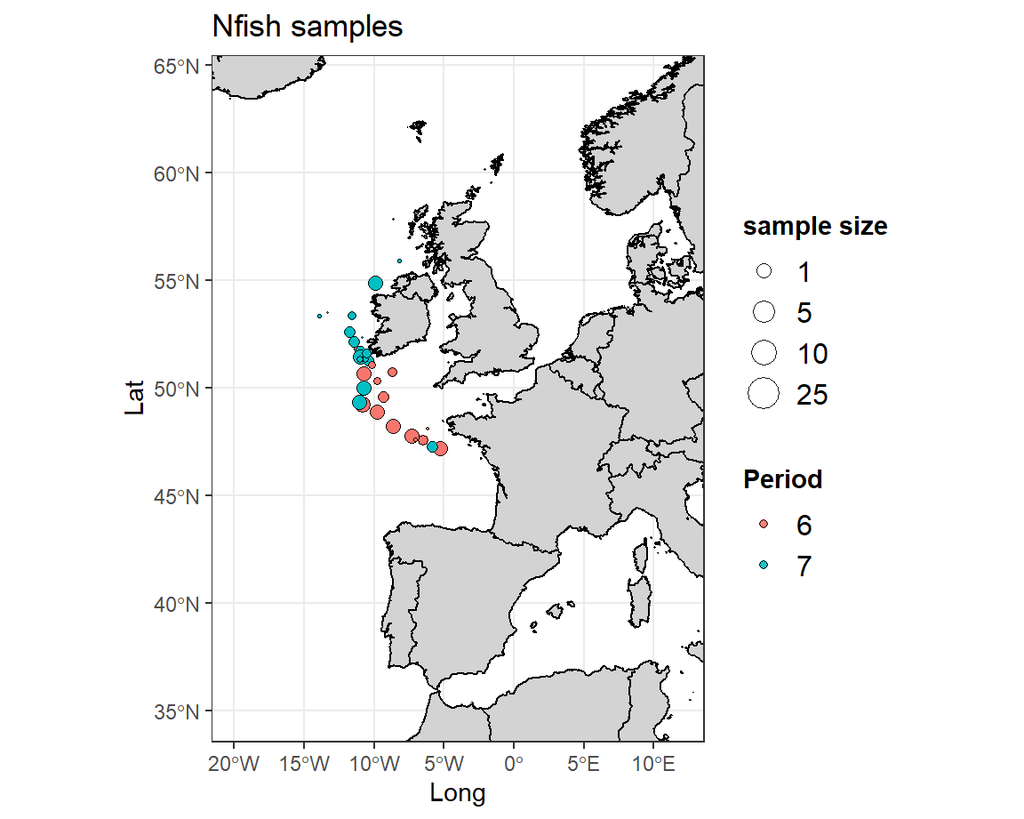

**Oocyte size frequency distribution by oocyte stage**

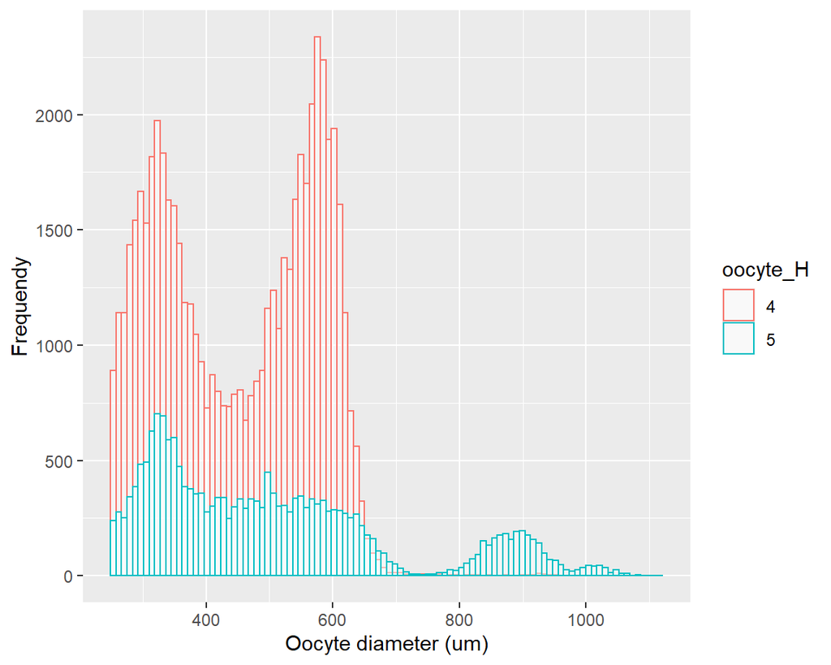

- Valid batch fecundity samples were considered as having oocyte stage 4 and 5, migratory nuclueus and hydrated respectively.
- Ploting the distribution of processed samples evidences that oocyte stage 4 was not valid as there was no clear hyatus.

**Gap in the oocyte size frequency distribution**

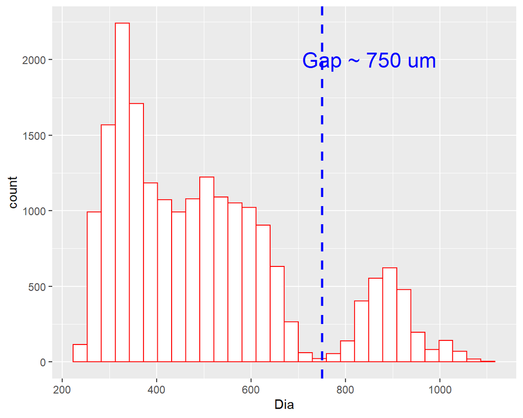

- Considering then only samples with oocyte stage 5, hydration, the size threshold to separate the batch oocytes was around 750 um.
- Then batch fecundity was estimated above counting the oocytes above this threshold.

**Batch fecundity > 750 um**

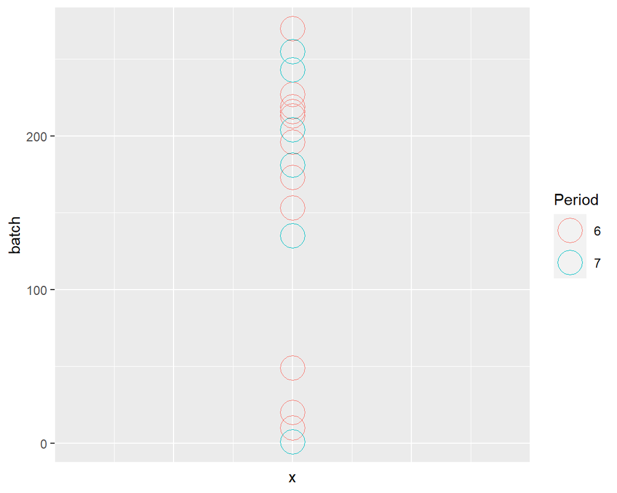

```
## # A tibble: 6 x 3
## # Groups:   Period [2]
##   Period Haul          nNcent
##   <fct>  <fct>          <int>
## 1 6      2022NL5400610      6
## 2 6      2022NL5400613      2
## 3 7      14                 2
## 4 7      16                 1
## 5 7      2022NL5000740      1
## 6 7      2022NL5000742      1
```

- When ploting the batch of these oocyte stage 5 samples, some of them have no fully recruited oocytes to the batch.
- Only batches above 100 oocytes/batch were considered, which gave a total number of 13 batch fecundity samples; 8 form the Period 6 and 5 from the Period 7.

**Fit regression**

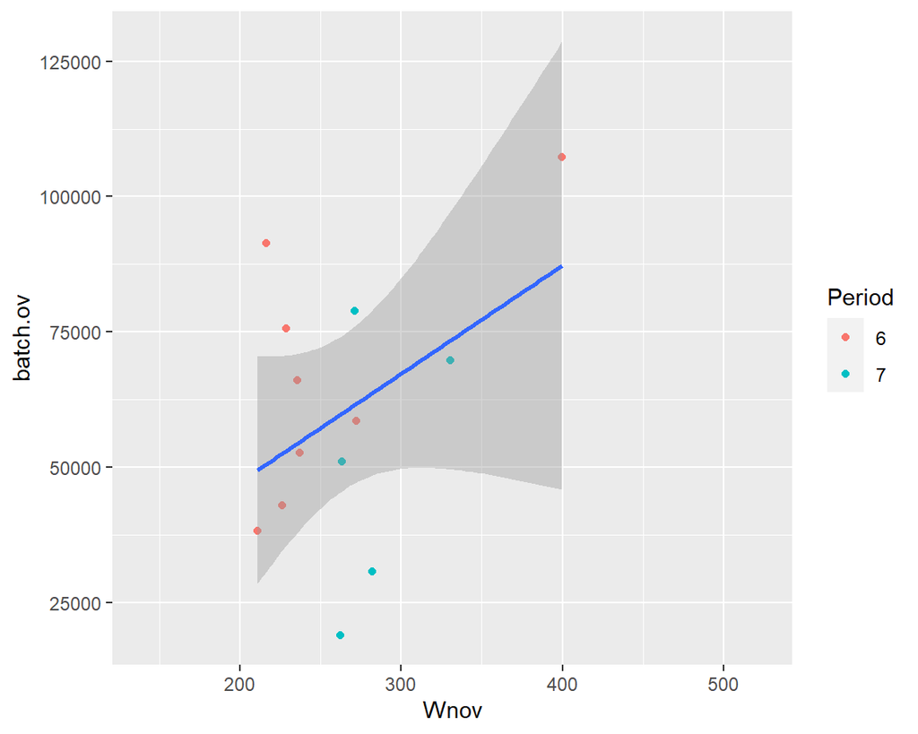

```r
# (Intercept)        Wnov
#   7280.5014    200.0639
#  Adjusted R-squared:  0.1769
```

- The individual observed batch fecundities are first modelled against the corresponding female gonad-free weights linear.
- It was assumed that the relationship is linear, weak.

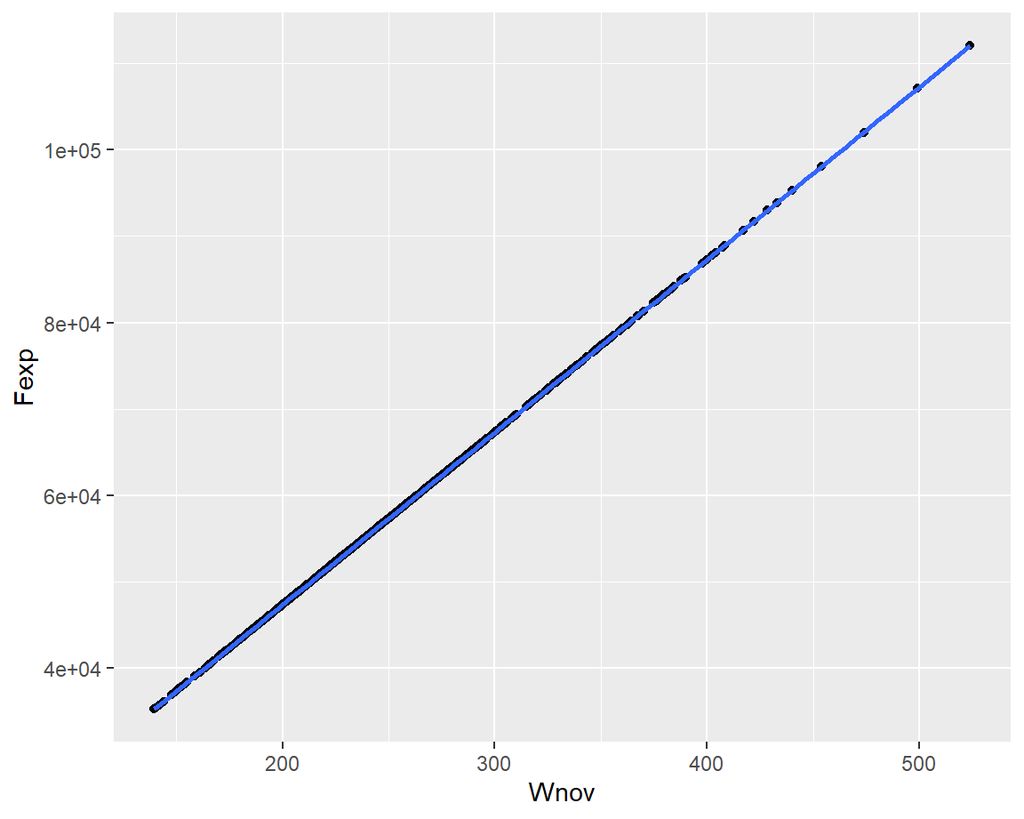

- This model is subsequently applied to all mature females in the sample to obtain the expected individual batch fecundity.

## 2.5 Spawning fraction (Sh)

Parameters by haul.

| Period | Haul | N | nMales | nFemales | n.Females.R | Wh | TotNh | Rh | Fh | Sh |
| --- | --- | --- | --- | --- | --- | --- | --- | --- | --- | --- |
| 6 | 1 | 40 | 15 | 25 | 25 | 303.360 | 40 | 0.502 | 65069.96 | 0.000 |
| 6 | 10 | 23 | 11 | 12 | 12 | NA | 23 | 0.487 | 46573.05 | 0.000 |
| 6 | 13 | 23 | 16 | 7 | 7 | NA | 23 | 0.483 | 61722.89 | 0.000 |
| 6 | 2 | 5 | 3 | 2 | 2 | NA | 5 | NA | NA | NA |
| 6 | 2022NL5400606 | 1 | 0 | 1 | 1 | NA | 1 | NA | NA | NA |
| 6 | 2022NL5400607 | 12 | 5 | 7 | 7 | NA | 12 | NA | NA | NA |
| 6 | 2022NL5400608 | 36 | 17 | 19 | 19 | NA | 36 | 0.491 | 83369.02 | 0.000 |
| 6 | 2022NL5400609 | 100 | 28 | 72 | 72 | 301.530 | 100 | 0.523 | 64740.86 | 0.029 |
| 6 | 2022NL5400610 | 107 | 73 | 34 | 27 | 230.083 | 100 | 0.490 | 51712.47 | 0.118 |
| 6 | 2022NL5400611 | 100 | 47 | 53 | 53 | 257.861 | 100 | 0.507 | 56884.47 | 0.000 |
| 6 | 2022NL5400613 | 101 | 63 | 38 | 37 | 277.510 | 100 | 0.513 | 60419.35 | 0.062 |
| 6 | 2022NL5400614 | 100 | 69 | 31 | 31 | 280.111 | 100 | 0.502 | 60887.30 | 0.000 |
| 6 | 2022NL5400615 | 100 | 45 | 55 | 55 | 240.869 | 100 | 0.523 | 53827.37 | 0.059 |
| 6 | 3 | 2 | 2 | 0 | 0 | NA | 2 | NA | NA | NA |
| 6 | 9 | 50 | 24 | 26 | 26 | 323.948 | 50 | 0.525 | 68773.99 | 0.200 |
| 7 | 14 | 16 | 12 | 4 | 4 | NA | 16 | NA | NA | NA |
| 7 | 15 | 2 | 2 | 0 | 0 | NA | 2 | NA | NA | NA |
| 7 | 16 | 36 | 3 | 33 | 3 | NA | 6 | NA | NA | NA |
| 7 | 17 | 1 | 1 | 0 | 0 | NA | 1 | NA | NA | NA |
| 7 | 20 | 4 | 3 | 1 | 1 | NA | 4 | NA | NA | NA |
| 7 | 2022NL5000740 | 50 | 31 | 19 | 19 | NA | 50 | 0.517 | 57633.43 | 0.111 |
| 7 | 2022NL5000741 | 50 | 25 | 21 | 21 | 220.056 | 46 | 0.488 | 50083.06 | 0.100 |
| 7 | 2022NL5000742 | 50 | 19 | 31 | 31 | 257.604 | 50 | 0.491 | 56838.27 | 0.000 |
| 7 | 2022NL5000743 | 50 | 23 | 27 | 27 | 228.520 | 50 | 0.510 | 51605.77 | NaN |
| 7 | 2022NL5000744 | 50 | 33 | 17 | 17 | NA | 50 | 0.518 | 49717.59 | NaN |
| 7 | 21 | 28 | 13 | 15 | 15 | NA | 28 | 0.478 | 71250.17 | NA |
| 7 | 40 | 4 | 3 | 1 | 1 | NA | 4 | NA | NA | NA |
| 7 | AE22010 | 1 | 0 | 1 | 1 | NA | 1 | NA | NA | NA |
| 7 | AE22011 | 57 | 27 | 24 | 24 | 237.619 | 51 | 0.520 | 53242.68 | 0.333 |
| 7 | AE22012 | 100 | 55 | 42 | 42 | 222.976 | 97 | 0.485 | 50608.34 | 0.333 |
| 7 | AE22013 | 53 | 32 | 21 | 21 | 361.755 | 53 | 0.489 | 75575.65 | 0.000 |
| 7 | AE22014 | 6 | 1 | 5 | 5 | NA | 6 | NA | NA | NA |
| 7 | AE22015 | 100 | 59 | 41 | 41 | 243.254 | 100 | 0.502 | 54256.51 | 0.000 |
| 7 | AE22016 | 100 | 43 | 53 | 53 | 209.925 | 96 | 0.494 | 48260.49 | 0.000 |
| 7 | AE22017 | 100 | 55 | 45 | 45 | 260.248 | 100 | 0.504 | 57313.82 | 0.103 |

- We set a threshold of 20 mature individuals in the haul to allow statistical meaning calculations by haul.
- More or less, more than half of them met the condition in each case, except in batch fecundity.
- Batch fecundity was estimated for all hauls together.
- Spawning fraction was estimated based on POFs method (day1day2) (SISP5)

# 3 Population parameters by Period

```r
# W:  Mean weight of mature females
# R:  Sex-ratio
# F:  Batch fecundity = average number of egg by mature female by spawning event (g)
# S:  Spawning fraction
```

## 3.1 Mean Weight

```
##       mean      var        cv
## 1 259.9794 84.54067 0.5702474
```

```
## # A tibble: 2 x 4
##   Period  mean   var    cv
## * <fct>  <dbl> <dbl> <dbl>
## 1 6       275.  125. 0.673
## 2 7       243.  136. 0.748
```

## 3.2 Mean Sex Ratio

```
##        mean          var         cv
## 1 0.5037291 8.793905e-06 0.00417823
```

```
## # A tibble: 2 x 4
##   Period  mean       var      cv
## * <fct>  <dbl>     <dbl>   <dbl>
## 1 6      0.508 0.0000186 0.00606
## 2 7      0.500 0.0000122 0.00494
```

## 3.3 Mean Batch Fecundity

```
##       mean     var       cv
## 1 57935.81 2725404 6.858701
```

```
## # A tibble: 2 x 4
##   Period   mean      var    cv
## * <fct>   <dbl>    <dbl> <dbl>
## 1 6      60840. 4972036.  9.04
## 2 7      54966. 3900617.  8.42
```

## 3.4 Mean Spawning fraction

```
##         mean          var         cv
## 1 0.07085477 0.0005801097 0.09048373
```

```
## # A tibble: 2 x 4
##   Period   mean      var     cv
## * <fct>   <dbl>    <dbl>  <dbl>
## 1 6      0.0440 0.000268 0.0781
## 2 7      0.104  0.00238  0.151
```

# 4 Summary mean parameters by period

Period 6: Adult parameters estimates for the 2022 Western horse mackerel DEPM survey.

| Period | Parameter | mean | var | cv |
| --- | --- | --- | --- | --- |
| 6 | Female Mean weight | 275.444 | 124.919 | 0.673 |
| 6 | Mean Sex Ratio | 0.508 | 0.000 | 0.006 |
| 6 | Mean Spawning Fraction | 0.044 | 0.000 | 0.078 |
| 6 | Mean batch fecundity | 60840.121 | 4972036.230 | 9.040 |
| 6 | Mean batch fecundity/g Female (Frel) | 220.880 | NA | NA |
| 6 | Daily n.eggs/g Female | 6.396 | NA | NA |

Period 7: Adult parameters estimates for the 2022 Western horse mackerel DEPM survey.

| Period | Parameter | mean | var | cv |
| --- | --- | --- | --- | --- |
| 7 | Female Mean weight | 243.450 | 136.128 | 0.748 |
| 7 | Mean Sex Ratio | 0.500 | 0.000 | 0.005 |
| 7 | Mean Spawning Fraction | 0.104 | 0.002 | 0.151 |
| 7 | Mean batch fecundity | 54966.238 | 3900616.907 | 8.424 |
| 7 | Mean batch fecundity/g Female (Frel) | 225.780 | NA | NA |
| 7 | Daily n.eggs/g Female | 15.014 | NA | NA |

# 5 Summary mean parameters

Adult parameters estimates for the 2022 Western horse mackerel DEPM survey.

| Parameter | mean | var | cv |
| --- | --- | --- | --- |
| Female Mean weight | 259.979 | 84.541 | 0.570 |
| Mean Sex Ratio | 0.504 | 0.000 | 0.004 |
| Mean Spawning Fraction | 0.071 | 0.001 | 0.090 |
| Mean batch fecundity | 57935.812 | 2725403.580 | 6.859 |
| Mean batch fecundity/g Female (Frel) | 222.848 | NA | NA |
| Daily n.eggs/g Female | 10.558 | NA | NA |

- Population parameters are estimated as the weighted mean of each haul for each parameter when combined periods.

```r
# --- WGMEGS 2016 (P6-P7): --- #

# Female mean weight (g)      281.22 g - 287.38
# Mean sex ratio              0.50     - 0.50
# Mean spawning fraction      0.10     - 0.33
# Frel (oo/f female)          157      - 331
# DF (oo/day.g female)        7.85     - 54.61


# ---- Literature ------------ #
#
# Frel (oo/f female)          205         (Karlou-Riga and Economidis, 1997)
#                             172 - 209   (Abaunza, 2003)
#                             124 - 175   (Gonsalves et al., 2009)
# Spawning fraction           9.1 - 33.9  (Gonsalves et al., 2009; based on migr. nucleus)
#                             7.6 - 33.3  (Gonsalves et al., 2009; based on migr. nucleus)
#                             14.7- 30.9  (Gonsalves et al., 2009; based on POF, 2d duration)
#                             9.8 - 20.6  (Gonsalves et al., 2009; based on POF, 3d duration)
#                             8.5         (Eltink, 1991; based on migratory nuclues)
# ---------------------------- #
```

# 6 Summary SSB

SSB by period based on aduts parameters by period and combined.

| Period | Daily fecundity | Total daily egg production(e+12) | SSB(kt) |
| --- | --- | --- | --- |
| 6 | 6.396 | 14.40 | 2258.779 |
| 7 | 15.014 | 1.35 | 89.970 |
| 6 | 10.558 | 14.40 | 1368.360 |
| 7 | 10.558 | 1.35 | 127.941 |

```r
# @ https://github.com/GersomCostas/mackerel_adults_MEGS
# @ https://github.com/ices-eg/wg_WGMEGS
```